# Travail Pratique 1

Equipe A

2025-02-10

### Plan de l’analyse

#### 1- Presentation des données

Ce dataset contient les métadonnées de plus de 700 000 films répertoriés dans l’ensemble de données TMDB. Il est mis à jour quotidiennement pour garantir la mise à jour de l’ensemble de données sur les films. Les points de données comprennent les acteurs, l’équipe, les mots-clés de l’intrigue, le budget, les revenus, les affiches, les dates de sortie, les langues, les sociétés de production, les pays, le nombre de votes TMDB et les moyennes des votes, les critiques, les recommandations.

**Description des variables**

- id : Identifiant unique pour chaque film.
- title : Titre du film.
- genres : Genres du film, combinés dans une seule chaîne de caractères (ex : Action-Comedy).
- original_language : Langue originale du film.
- overview : Résumé ou description du film.
- popularity : Score de popularité du film.
- production_companies : Compagnies de production associées au film, listées dans une chaîne de caractères.
- release_date : Date de sortie du film.
- budget : Budget du film en dollars.
- revenue : Revenu généré par le film en dollars.
- runtime : Durée du film en minutes.
- status : Statut du film (ex : Released).
- tagline : Slogan du film.
- vote_average : Moyenne des votes pour le film.
- vote_count : Nombre total de votes reçus par le film.
- credits : Principaux acteurs et membres de l’équipe du film.
- keywords : Mots-clés associés au film, listés dans une chaîne de caractères.
- poster_path : Chemin vers l’image de l’affiche du film.
- backdrop_path : Chemin vers l’image de fond du film.
- recommendations : Identifiants de films recommandés basés sur ce film, listés dans une chaîne de caractères.

#### Importation des données

```r
movies <- read.csv("data/movies.csv")
print(nrow(movies))
```

```
## [1] 722317
```

```r
print( ncol(movies))
```

```
## [1] 20
```

#### 2- Exploration des données

```r
# Statistique descriptive

skim(movies)
```

Data summary

| Name | movies |
| --- | --- |
| Number of rows | 722317 |
| Number of columns | 20 |
| _______________________ |  |
| Column type frequency: |  |
| character | 13 |
| numeric | 7 |
| ________________________ |  |
| Group variables | None |

**Variable type: character**

| skim_variable | n_missing | complete_rate | min | max | empty | n_unique | whitespace |
| --- | --- | --- | --- | --- | --- | --- | --- |
| title | 0 | 1 | 0 | 234 | 4 | 575321 | 0 |
| genres | 0 | 1 | 0 | 129 | 210317 | 11050 | 0 |
| original_language | 0 | 1 | 2 | 2 | 0 | 167 | 0 |
| overview | 0 | 1 | 0 | 999 | 118243 | 541884 | 6 |
| production_companies | 0 | 1 | 0 | 679 | 384926 | 147600 | 0 |
| release_date | 0 | 1 | 0 | 10 | 51549 | 41474 | 0 |
| status | 0 | 1 | 7 | 15 | 0 | 6 | 0 |
| tagline | 0 | 1 | 0 | 284 | 613841 | 95910 | 4 |
| credits | 0 | 1 | 0 | 7172 | 224714 | 423217 | 0 |
| keywords | 0 | 1 | 0 | 1258 | 511678 | 119803 | 0 |
| poster_path | 0 | 1 | 0 | 32 | 184493 | 483219 | 0 |
| backdrop_path | 0 | 1 | 0 | 32 | 499106 | 197370 | 0 |
| recommendations | 0 | 1 | 0 | 156 | 686301 | 32104 | 0 |

**Variable type: numeric**

| skim_variable | n_missing | complete_rate | mean | sd | p0 | p25 | p50 | p75 | p100 | hist |
| --- | --- | --- | --- | --- | --- | --- | --- | --- | --- | --- |
| id | 0 | 1.00 | 526920.12 | 253200.15 | 2 | 328914.0 | 533351.0 | 737872.0 | 968161 | ▃▇▇▇▇ |
| popularity | 0 | 1.00 | 1.92 | 23.69 | 0 | 0.6 | 0.6 | 1.3 | 8764 | ▇▁▁▁▁ |
| budget | 0 | 1.00 | 404345.28 | 8242867.85 | 0 | 0.0 | 0.0 | 0.0 | 5000000000 | ▇▁▁▁▁ |
| revenue | 0 | 1.00 | 1007747.33 | 20483206.23 | -12 | 0.0 | 0.0 | 0.0 | 2920357254 | ▇▁▁▁▁ |
| runtime | 34335 | 0.95 | 199.09 | 85842.57 | 0 | 5.0 | 50.0 | 90.0 | 50505050 | ▇▁▁▁▁ |
| vote_average | 0 | 1.00 | 2.45 | 3.18 | 0 | 0.0 | 0.0 | 5.6 | 10 | ▇▁▂▂▁ |
| vote_count | 0 | 1.00 | 28.48 | 396.58 | 0 | 0.0 | 0.0 | 2.0 | 34857 | ▇▁▁▁▁ |

- Détection des valeurs manquantes

```r
sum(is.na(movies))
```

```
## [1] 34335
```

```r
# supprimons toutes les liqnes comportant des données manquantes

movies <- na.omit(movies)
nrow(movies)
```

```
## [1] 687982
```

```r
#Verifions les films qui sont sortis ou non

# Comptons le nombre de films par statut
status_counts <- movies %>%
  group_by(status) %>%
  summarise(count = n())

print(status_counts)
```

```
## # A tibble: 6 × 2
##   status           count
##   <chr>            <int>
## 1 Canceled           208
## 2 In Production     1112
## 3 Planned           2157
## 4 Post Production    931
## 5 Released        683414
## 6 Rumored            160
```

**Detection de données aberrantes**

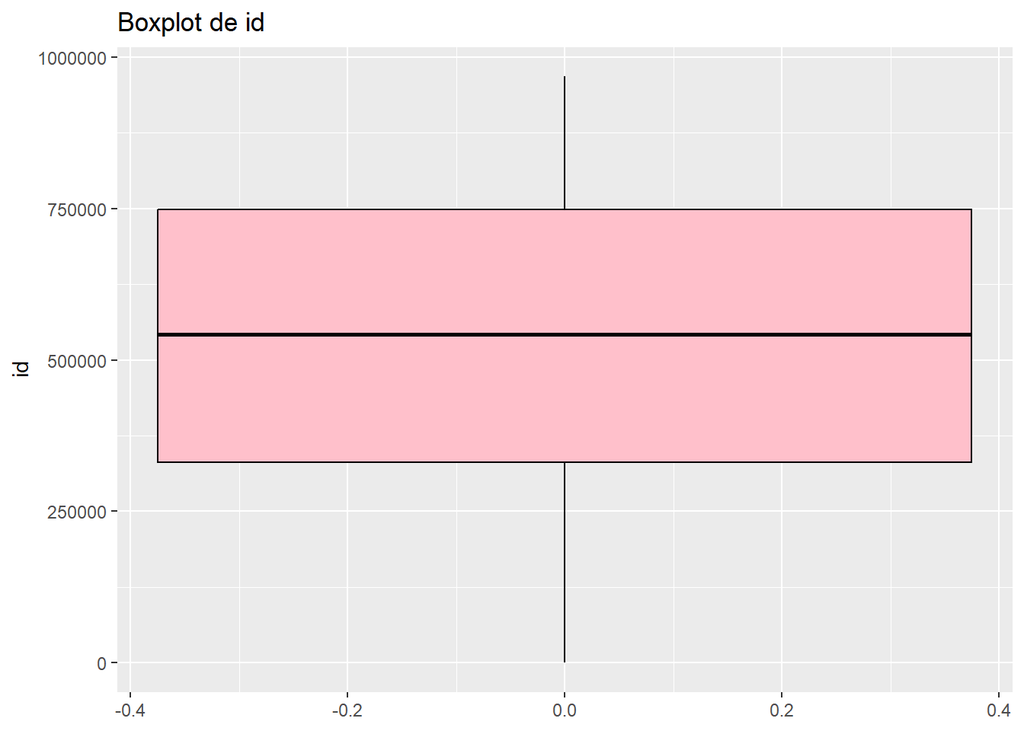

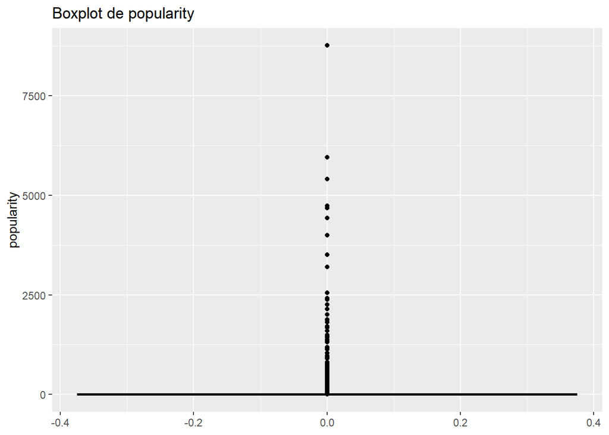

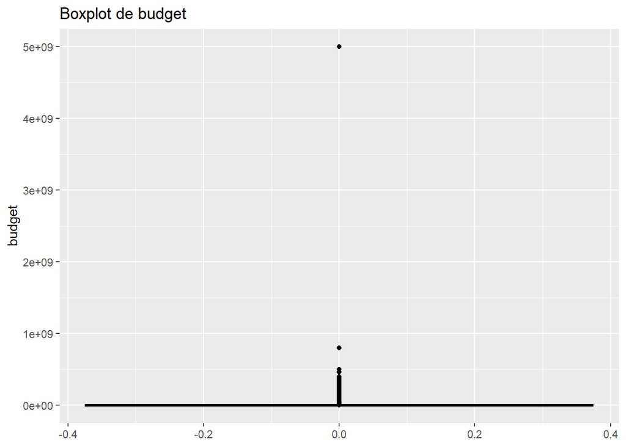

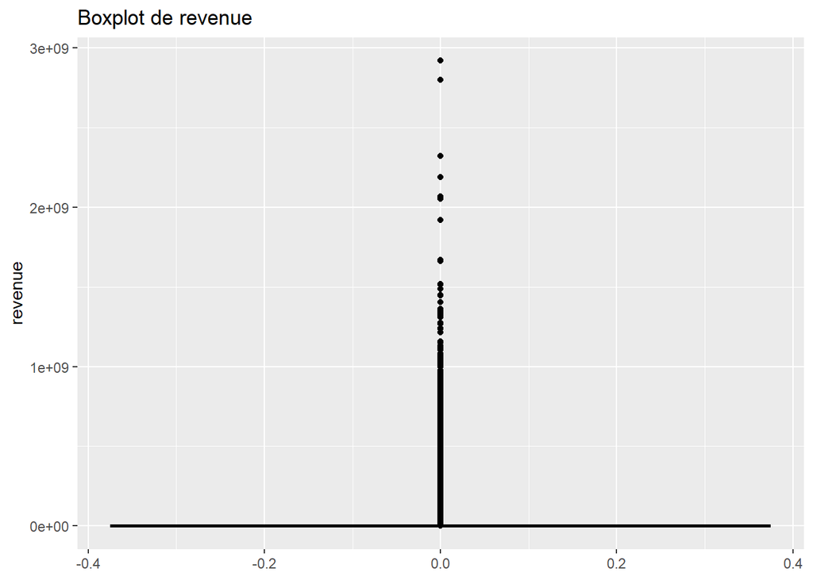

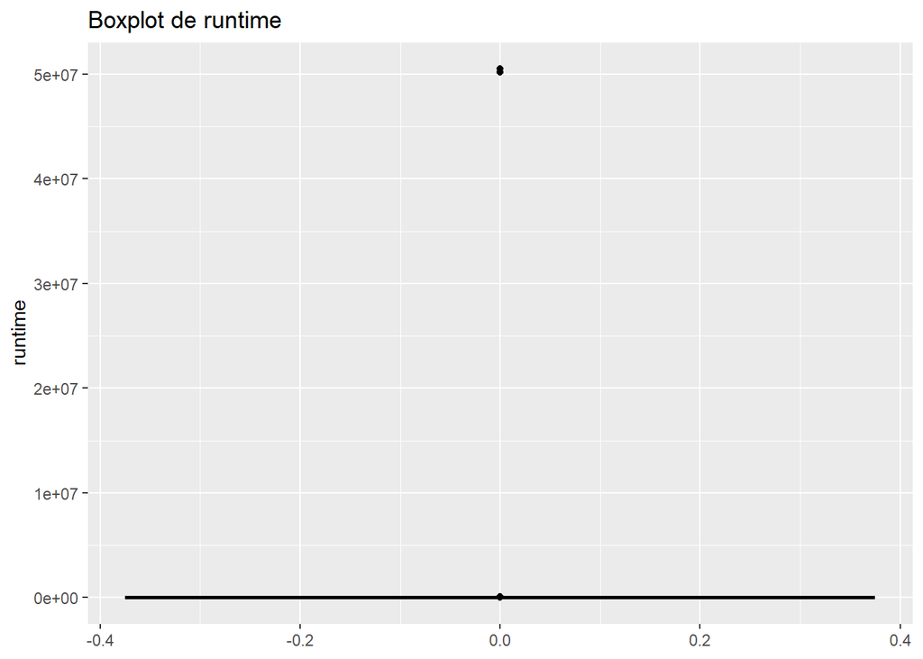

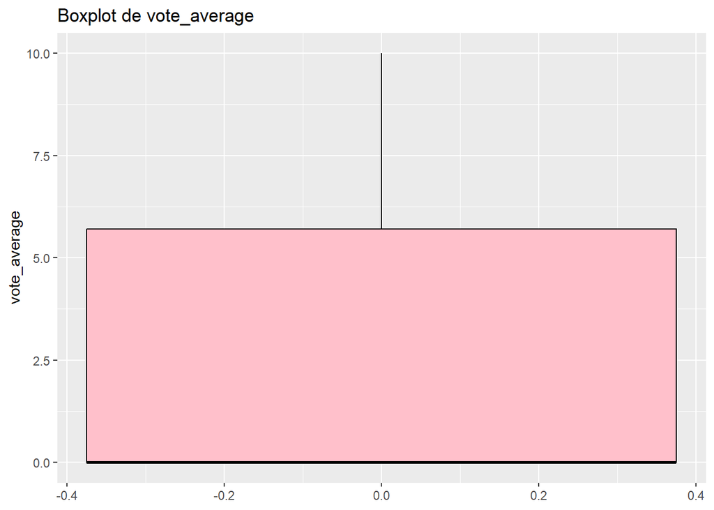

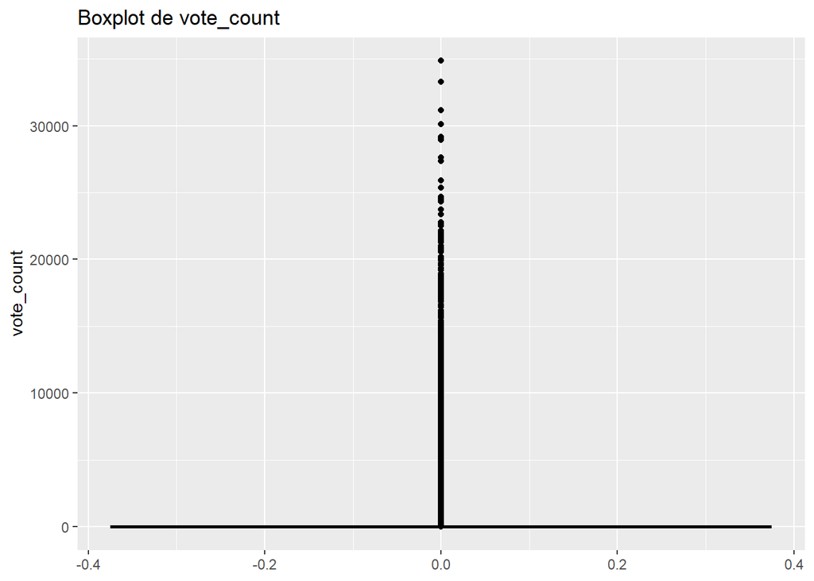

```r
# Boîtes à moustaches pour identifier les valeurs aberrantes
numeric_vars <- sapply(movies, is.numeric)
data_numeric <- movies[, numeric_vars]
lapply(names(data_numeric), function(x) {
  ggplot(movies, aes_string(y = x)) +
    geom_boxplot(fill = "pink", color = "black") +
    ggtitle(paste("Boxplot de", x))
})
```

Supprimons aussi certaines colonnes comme: poster_path, backdrop_path et recommendations, qui ne nous sont pas utiles.

```r
# Suppressions des colonnes spécifiées
movies_clean <- movies %>%
  select(-poster_path, -backdrop_path, -recommendations)
ncol(movies_clean)
```

```
## [1] 17
```

#### 3- Analyse descriptive

Distribution des films par :

- **Année de sortie**

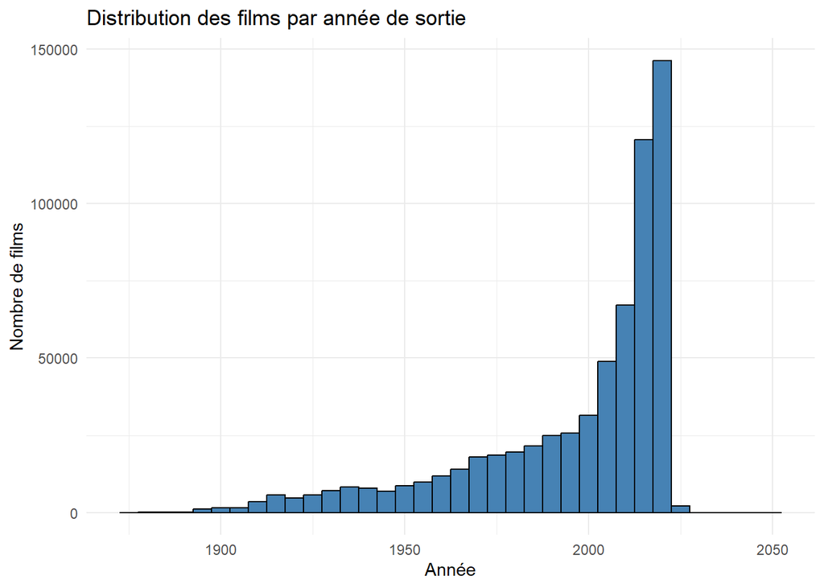

```r
movies_clean$release_date <- as.Date(movies_clean$release_date, format="%Y-%m-%d")

movies_clean$release_year <- as.numeric(format(movies_clean$release_date, "%Y"))

ggplot(movies_clean, aes(x = release_year)) +
  geom_histogram(binwidth = 5, fill="steelblue", color="black") +
  labs(title="Distribution des films par année de sortie", x="Année", y="Nombre de films") +
  theme_minimal()
```

- **Genre**

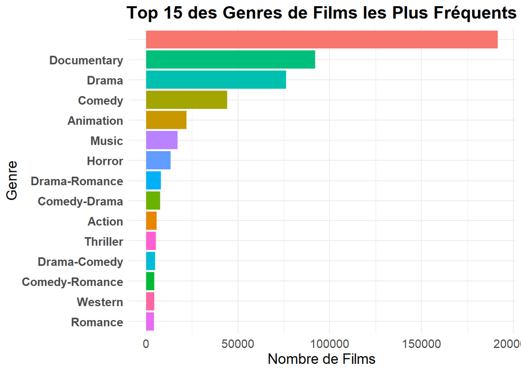

```r
data_genres <- movies_clean %>%
  filter(!is.na(genres)) %>%
  mutate(genres = str_replace_all(genres, " ", "")) %>%
  separate_rows(genres, sep = ",") %>%
  count(genres, sort = TRUE)

top_genres <- data_genres %>%
  slice_max(n, n = 15)

ggplot(top_genres, aes(x = reorder(genres, n), y = n, fill = genres)) +
  geom_col(show.legend = FALSE) +
  coord_flip() +
  labs(
    title = "Top 15 des Genres de Films les Plus Fréquents",
    x = "Genre",
    y = "Nombre de Films"
  ) +
  theme_minimal() +
  theme(
    text = element_text(size = 14),
    axis.text.y = element_text(face = "bold"),
    plot.title = element_text(hjust = 0.5, face = "bold")
  )
```

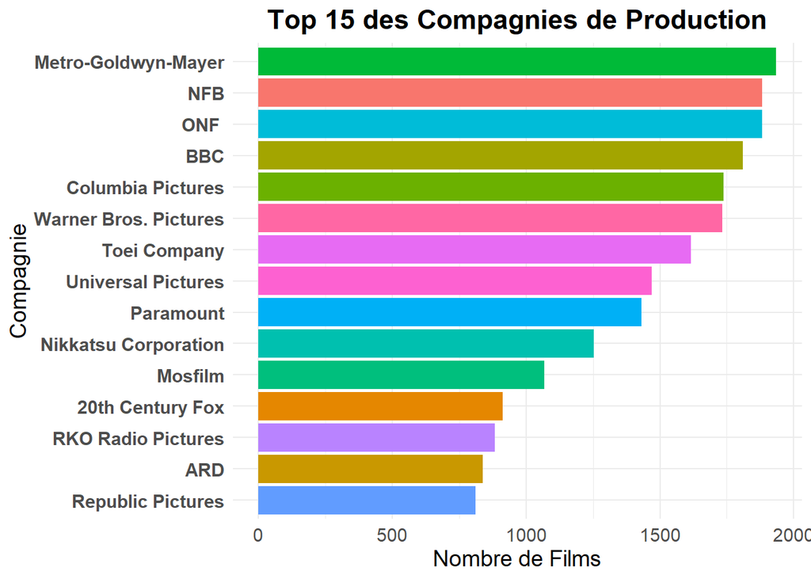

```r
data_production <- movies_clean %>%
  filter(!is.na(production_companies) & production_companies != "") %>%
  mutate(production_companies = str_replace_all(production_companies, "[|]", ",")) %>%  # Remplace les séparateurs
  separate_rows(production_companies, sep = ",") %>%
  count(production_companies, sort = TRUE)

top_production <- data_production %>%
  slice_max(n, n = 15)

ggplot(top_production, aes(x = reorder(production_companies, n), y = n, fill = production_companies)) +
  geom_col(show.legend = FALSE) +
  coord_flip() +
  labs(
    title = "Top 15 des Compagnies de Production",
    x = "Compagnie",
    y = "Nombre de Films"
  ) +
  theme_minimal() +
  theme(
    text = element_text(size = 14),
    axis.text.y = element_text(face = "bold"),
    plot.title = element_text(hjust = 0.5, face = "bold")
  )
```

- Budget

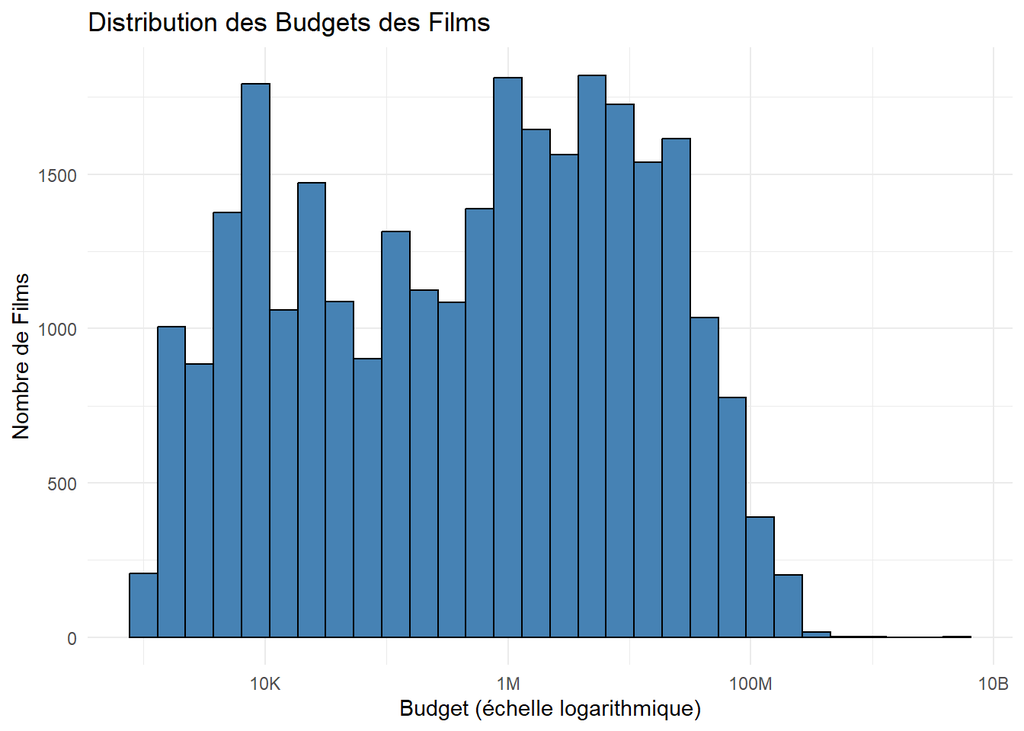

```r
budget_data <- movies_clean %>%
  filter(!is.na(budget) & budget > 1000)  # Supprime les budgets nuls et très faibles

ggplot(budget_data, aes(x = budget)) +
  geom_histogram(bins = 30, fill = "steelblue", color = "black") +
  scale_x_log10(labels = scales::label_number(scale_cut = scales::cut_short_scale())) +  # Nouvelle notation
  labs(
    title = "Distribution des Budgets des Films",
    x = "Budget (échelle logarithmique)",
    y = "Nombre de Films"
  ) +
  theme_minimal()
```

- **Revenus**

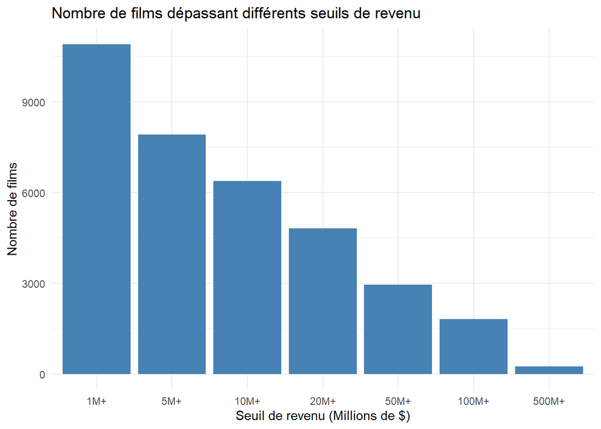

```r
# Définissons 7 seuils de revenu en millions pour avoir une idées de combien de film peuvent atteindre combien de revenue
revenue_thresholds <- c(1, 5, 10, 20, 50, 100, 500) # En millions

# Dataframe pour quantité de film dépassant chaque seuils
revenue_counts <- data.frame(
  Seuil = factor(paste0(revenue_thresholds, "M+"), levels = paste0(revenue_thresholds, "M+")),  # Formater les labels pour affichage graphique
  Nombre_de_films = sapply(revenue_thresholds * 1e6, function(threshold) sum(movies_clean$revenue > threshold, na.rm = TRUE))
)


ggplot(revenue_counts, aes(x = Seuil, y = Nombre_de_films)) +
  geom_bar(stat="identity", fill="steelblue") +
  labs(title="Nombre de films dépassant différents seuils de revenu",
       x="Seuil de revenu (Millions de $)",
       y="Nombre de films") +
  theme_minimal()
```

- **Analyse des moyennes et médianes importantes**

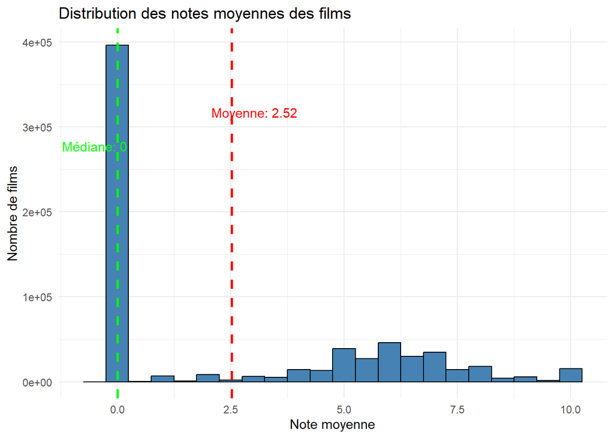

```r
#Moyenne et médiannes des notes de film
mean_vote <- mean(movies_clean$vote_average, na.rm = TRUE)
median_vote <- median(movies_clean$vote_average, na.rm = TRUE)

# Histogramme pour voir la distribution des notes des films
ggplot(movies_clean, aes(x = vote_average)) +
  geom_histogram(binwidth = 0.5, fill="steelblue", color="black") +
  geom_vline(aes(xintercept = mean_vote), color="red", linetype="dashed", size=1, show.legend = TRUE) +
  geom_vline(aes(xintercept = median_vote), color="green", linetype="dashed", size=1, show.legend = TRUE) +
  labs(title = "Distribution des notes moyennes des films",
       x = "Note moyenne",
       y = "Nombre de films") +
  theme_minimal() +
  annotate("text", x = mean_vote + 0.5, y = max(table(movies_clean$vote_average, useNA = "no")) * 0.8,
           label = paste("Moyenne:", round(mean_vote, 2)), color = "red") +
  annotate("text", x = median_vote - 0.5, y = max(table(movies_clean$vote_average, useNA = "no")) * 0.7,
           label = paste("Médiane:", round(median_vote, 2)), color = "green")
```

La mojorité des film reçoivent une note de 0.(Peut-être valeur par défaut) Excluant les reçoivant une note de 0 on note qu’une grande partie des film ont une note supérieure à 5 et inférieure à 8. En plus de cela une minorité importante de film recoivent une note parfaite de 10/10.

- **Durée des films**

Après une observation des durées de films, nous remarquons plusieurs choses intéressantes:

```r
movies_clean %>%
  filter(!is.na(runtime)) %>%
  arrange(desc(runtime)) %>%
  head(10) %>%
  select(title, runtime)
```

```
##                                       title  runtime
## 1   Mr Marcus FriendPop Facebook Adventures 50505050
## 2  Mr Marcus FriendBoop Facebook Adventures 50189181
## 3                                 Logistics    51420
## 4                                  Ambiancé    43200
## 5                      Modern Times Forever    14400
## 6                Svalbard minutt for minutt    13319
## 7                                 Cinématon    12480
## 8                                 Cinématon    12480
## 9                              Beijing 2003     9000
## 10                  Untitled #125 (Hickory)     7200
```

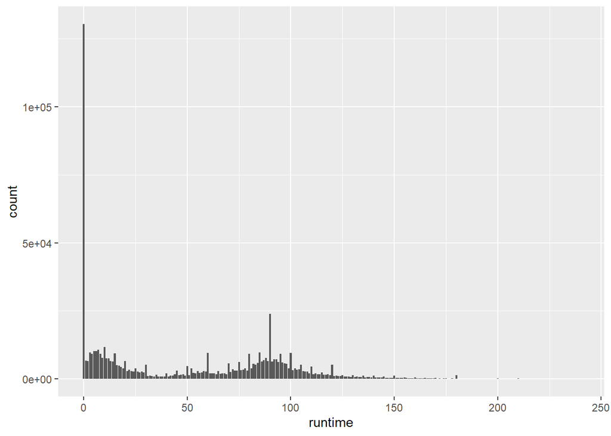

```r
runtime_data = movies_clean %>%
  filter(runtime < 240) # Limitons-nous à des films de moins de 4h

ggplot(runtime_data, aes(runtime)) +
  geom_bar()
```

L’histogramme de la durée des films de moins de 4h nous permet d’obtenir plusieurs informations :  
1. On observe une distinction entre les courts métrages (10 min en moyenne) et des longs métrages (1h30 en moyenne).  
2. Il existe beaucoup de films dont la durée est nulle: 130300 au total.

#### 4- Analyse exploratoire avancée

**Corrélations entre variables :**

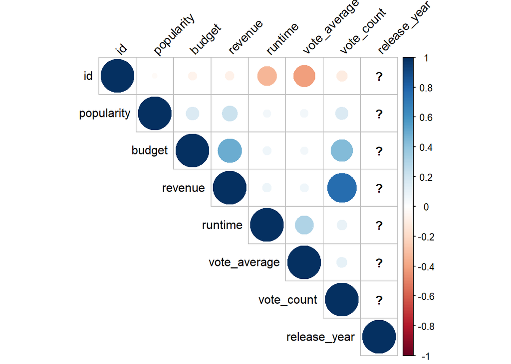

```r
movies_corr <- cor(
  movies_clean %>%
    filter(runtime < 240) %>%
    select_if(is.numeric)
  )

corrplot(movies_corr, type="upper", tl.col="black", tl.srt=45)
```

Nous observons une relativement forte corrélation entre le revenu des films et le nombre de votes. Cela peut s’expliquer par le fait que plus un film fait d’entrées, plus ses revenus sont élevés et plus de personnes peuvent le noter.  
Nous observons une faible corrélation positive entre le budget et le revenu, ainsi qu’entre le budget et le nombre de votes.

#### 5- Visualisation des données

**Graphiques de distribution**

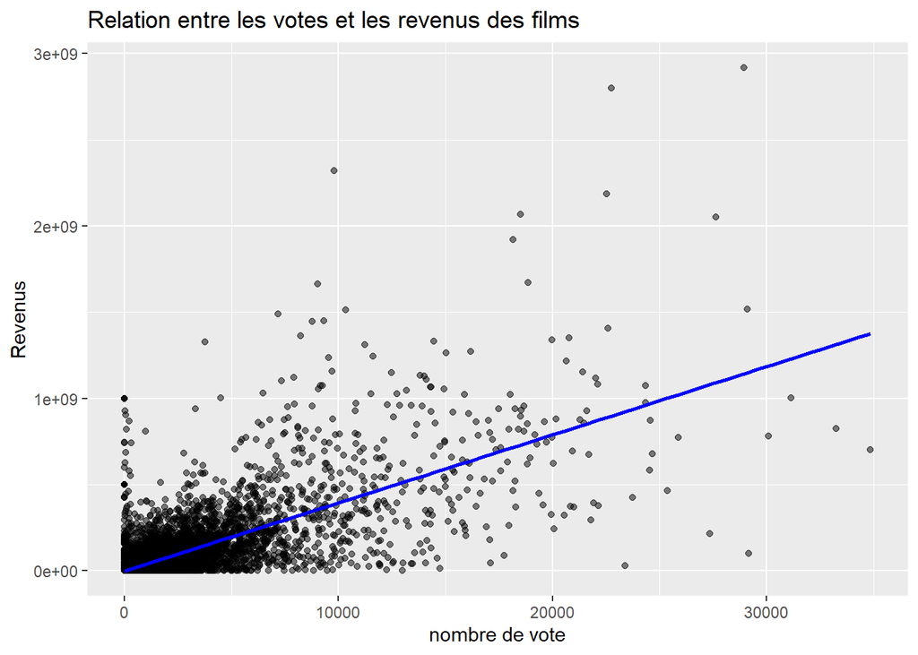

```r
ggplot(movies_clean, aes(x = vote_count, y = revenue)) +
  geom_point(alpha = 0.5) +
  geom_smooth(method = "lm", color = "blue") +
  labs(title = "Relation entre les votes et les revenus des films", x = "nombre de vote", y = "Revenus")
```

Nous remarquons une tendence générale positive entre le nombre de vote et les revenus. Cela peut suggèrer que les films avec plus de votes ont tendance à générer plus de revenus, ce qui peut indiquer que des films plus populaires ou mieux reçus attirent plus d’audience ou sont mieux monétisés.

#### 6- Modélisation prédictive potentielle

- Prédiction de revenue d’un film :
- Régression catégorielle/logistique: Prédiction de la rentabilité

```r
movies_r <- movies_clean %>%
  mutate(rentability = ifelse(revenue > budget, 1, 0))


glm_rentability <- glm(rentability ~ budget + popularity + vote_average + vote_count,
                        data = movies_r, family = binomial)
summary(glm_rentability)
```

```
##
## Call:
## glm(formula = rentability ~ budget + popularity + vote_average +
##     vote_count, family = binomial, data = movies_r)
##
## Coefficients:
##                Estimate Std. Error z value Pr(>|z|)
## (Intercept)  -5.495e+00  2.187e-02 -251.22  < 2e-16 ***
## budget        5.400e-09  1.132e-09    4.77 1.84e-06 ***
## popularity    4.928e-03  4.441e-04   11.10  < 2e-16 ***
## vote_average  2.786e-01  3.426e-03   81.33  < 2e-16 ***
## vote_count    3.380e-03  4.307e-05   78.48  < 2e-16 ***
## ---
## Signif. codes:  0 '***' 0.001 '**' 0.01 '*' 0.05 '.' 0.1 ' ' 1
##
## (Dispersion parameter for binomial family taken to be 1)
##
##     Null deviance: 129771  on 687981  degrees of freedom
## Residual deviance:  92136  on 687977  degrees of freedom
## AIC: 92146
##
## Number of Fisher Scoring iterations: 8
```

La régression montre que tous les prédicteurs ont un effet significatif sur la rentabilité d’un film, avec des valeurs de p inférieures à 2e-16 pour la plupart des variables. Le nombre de votes influence cette probabilité, chaque vote supplémentaire l’augmentant de 3.38e-03. La moyenne des votes a un impact important indiquant que les films mieux notés sont plus susceptibles d’être rentables. La popularité a également une influence positive suggérant que les films bénéficiant d’une forte visibilité ont de meilleures chances de succès. Le budget a une influence bien plus modeste que les autres facteurs. Avec une déviance résiduelle de 92 136 et un AIC de 92 146, le modèle montre de bonnes capacités prédictives.